# From DADA2 output to a Phyloseq object

Jonathan Rondeau-Leclaire & Claude Opus 5.5

2026-10-26

**About this tutorial**

The DADA2 tutorial ended with two tables: sequences (ASV counts per sample) and taxonomy. Before making analyses, we will clean them up and bundle them into a `phyloseq` object. That object is the starting point of the community composition tutorial, the tutorial that follows this one.

Along the way, we’ll take the time to look at the data. Knowing it well is the best way to catch problems early!

We use the raw 16S tables from [Poirier S., Rondeau-Leclaire J., et al 2026](https://www.sciencedirect.com/science/article/pii/S0048969726002846) (urban air samples).

# 1 Setup

Load the following packages; you might need to install some of them.

```r
pacman::p_load(mgx.tools, tidyverse, phyloseq, decontam, kableExtra, knitr)
```

## 1.1 Load the data

Three files: the sequence table and the taxonomy table (both from DADA2), and the sample metadata. If you followed the DADA2 tutorial, you already have the `.RDS` files; replace the URLs with your own output.

```r
repo <- 'https://raw.githubusercontent.com/jorondo1/urban_bioaerosols/main/data'

seqtab   <- read_rds(file.path(repo, '16S/4_taxonomy/seqtab.RDS'))
taxonomy <- read_rds(file.path(repo, '16S/4_taxonomy/taxonomy.RDS'))
metadata <- read_delim(file.path(repo, 'metadata/metadata_2022_samples_final.csv'), delim = ';')
```

```r
dim(seqtab)   # samples x ASVs
```

```
## [1]   174 24695
```

```r
dim(taxonomy) # ASVs x ranks
```

```
## [1] 24695     6
```

Each column of `seqtab` is an ASV, and each row of `taxonomy` describes one ASV. They should be in the same order:

```r
identical(colnames(seqtab), rownames(taxonomy))
```

```
## [1] TRUE
```

The code below expects the taxonomy columns to be named `Kingdom`, `Phylum`, `Class`, `Order`, `Family`, `Genus`. Check yours with `colnames(taxonomy)`. If they differ (e.g. lowercase from DECIPHER), rename them: `colnames(taxonomy) <- c("Kingdom", "Phylum", ...)`. This will also make plotting simpler because we usually want the ranks capitalised.

## 1.2 Subset samples [optional]

For all sorts of reasons, you might not want to keep all of your samples. Here, our sequencing run also contained controls (ideally!) and samples from another side-project. In this specific project, the metadata table tells us which samples belong to the study: they have a sampling `time` and the `control` column value is FALSE.

```r
count(metadata, time, control)
```

```
## # A tibble: 8 × 3
##   time   control     n
##   <chr>  <lgl>   <int>
## 1 Fall   FALSE      65
## 2 Fall   TRUE        1
## 3 None   FALSE       9
## 4 None   TRUE        3
## 5 Spring FALSE      65
## 6 Spring TRUE        1
## 7 Summer FALSE      27
## 8 Summer TRUE        1
```

```r
meta_study <- filter(metadata, time != 'None' & !control)
```

**Metadata table missing something?**

Ideally, your metadata table tells you which samples to keep. If not, write a short script that imports your metadata, adds the missing columns, and exports it again (e.g. as an `.rds` file). Run it before this one. When you spot errors or missing variables later in your project, fix them there, then rerun both scripts. For inspiration, see [this script](https://github.com/jorondo1/OrchardPhyllosphereInterannual/blob/main/src/0.3.2.Metadata_phyloseq.R) from Boutin et al., 2026.

Are all study samples from the metadata found in the sequence table? This should return `character(0)` (an empty vector). If not, those samples are missing from the sequence table or misnamed; fix them in your metadata script (see above).

```r
setdiff(meta_study$sample_id, rownames(seqtab))
```

```
## character(0)
```

And which sequenced samples are we leaving out? If a sample you sequenced is missing from your metadata, it will also show up here:

```r
setdiff(rownames(seqtab), meta_study$sample_id)
```

```
##  [1] "120min-avr"               "120min-avr-B"
##  [3] "15min-oct"                "22-A-QC-Q15-B"
##  [5] "22-E-MTL-23A-B"           "22-S-SHER-SH07-B"
##  [7] "30min-oct"                "60min-avr"
##  [9] "60min-avr-B"              "60min-oct"
## [11] "Controle-blanc-12h00-PM"  "Couloir-D8-3225"
## [13] "CTRL-PCR-neg-Laforest-P5" "CTRL-PCR-pos-Laforest-P5"
## [15] "D8-3044"                  "D8-3046"
## [17] "oct-B"
```

Controls and a handful of libraries from another project. We’ll come back for the controls later.

# 2 Build the phyloseq object

## 2.1 The what?

A `phyloseq` object keep multiple tables in sync, like a small relational database: every sample and every ASV is found in each table, no more, no fewer. We’ll focus on three table types for now:

| Table | Function | Contents |
| --- | --- | --- |
| OTU table | `otu_table()` | Read counts, samples × ASVs |
| Taxonomy table | `tax_table()` | Taxonomy of each ASV |
| Sample data | `sample_data()` | Metadata of each sample |

When you remove a sample or an ASV, phyloseq removes it from every table. No risk of misaligned tables! Note that you can also add phylogenetic trees to these objects; but let’s keep that for another tutorial…

## 2.2 Build it!

A few things to check or fix if you are using your own data instead of the provided toy dataset:

- `sample_data()` needs the sample names as row names, hence `column_to_rownames()`.
- `otu_table()` and `tax_table()` accept a matrix-type object; you can convert them using `as.matrix()` if `phyloseq()` throws an error

```r
ps_raw <- phyloseq(
  otu_table(seqtab[meta_study$sample_id, ], taxa_are_rows = FALSE),
  tax_table(taxonomy),
  sample_data(column_to_rownames(meta_study, 'sample_id'))
)
ps_raw # look at it!
```

```
## phyloseq-class experiment-level object
## otu_table()   OTU Table:         [ 24695 taxa and 157 samples ]
## sample_data() Sample Data:       [ 157 samples by 31 sample variables ]
## tax_table()   Taxonomy Table:    [ 24695 taxa by 6 taxonomic ranks ]
```

We dropped samples, so some ASVs might now have zero reads across all samples. `taxa_sums()` gives the total reads of each ASV; `prune_taxa()` keeps the ASVs for which the condition is `TRUE`.

```r
ps_raw <- prune_taxa(taxa_sums(ps_raw) > 0, ps_raw)
ps_raw
```

```
## phyloseq-class experiment-level object
## otu_table()   OTU Table:         [ 23898 taxa and 157 samples ]
## sample_data() Sample Data:       [ 157 samples by 31 sample variables ]
## tax_table()   Taxonomy Table:    [ 23898 taxa by 6 taxonomic ranks ]
```

A few other functions you’ll use all the time:

```r
nsamples(ps_raw)              # number of samples
```

```
## [1] 157
```

```r
ntaxa(ps_raw)                 # number of ASVs
```

```
## [1] 23898
```

```r
head(sample_names(ps_raw))    # sample names (showing first 6)
```

```
## [1] "22-S-MTL-01A" "22-S-MTL-02A" "22-S-MTL-03A" "22-S-MTL-04A" "22-S-MTL-05B"
## [6] "22-S-MTL-06C"
```

```r
sum(sample_sums(ps_raw))      # total number of reads
```

```
## [1] 3808179
```

# 3 Explore your samples

## 3.1 Sequencing depth

`sample_sums()` gives the number of reads in each sample. Look at the smallest ones:

```r
sample_sums(ps_raw) %>% sort() %>% head(10)
```

```
## 22-S-SHER-SH07 22-E-SHER-SH09 22-A-SHER-SH08 22-A-SHER-SH12 22-A-SHER-SH13
##             21           1879           5291           7261           7858
## 22-E-SHER-SH10 22-S-SHER-SH01 22-E-SHER-SH05   22-A-MTL-01A 22-S-SHER-SH11
##          10252          11813          12182          14815          15097
```

Or build a histogram to see how depth is distributed:

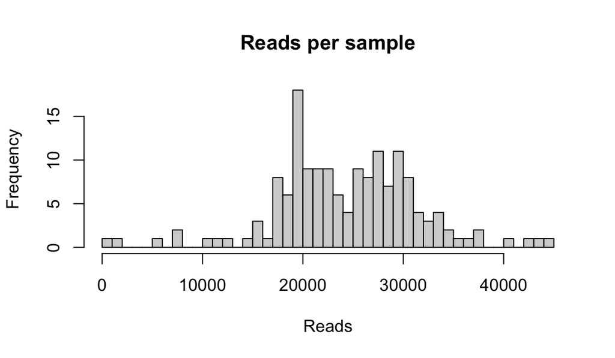

```r
hist(sample_sums(ps_raw), breaks = 50,
     main = 'Reads per sample', xlab = 'Reads')
```

In this case, most samples have 15,000 to 30,000 reads. But `22-S-SHER-SH07` has only 21 reads: that sample probably failed sequencing. `22-E-SHER-SH09` is also very low. Keep them in mind for now; we’ll take action later.

**Your data will differ.** With very deep samples, a histogram of log-reads may be easier to read. Depth matters for later analyses (especially rarefaction, see the next tutorial); discuss it with your PI.

Here, we’ll already take action and remove the super-low count sample, because 21 reads is a ridiculous number when the average sample has 24,256 reads!

```r
ps_nonempty <- prune_samples(sample_sums(ps_raw)>21, ps_raw) %>%
  prune_taxa(taxa_sums(.) > 0, .) # always flush the all-zero ASVs
ps_nonempty
```

```
## phyloseq-class experiment-level object
## otu_table()   OTU Table:         [ 23898 taxa and 156 samples ]
## sample_data() Sample Data:       [ 156 samples by 31 sample variables ]
## tax_table()   Taxonomy Table:    [ 23898 taxa by 6 taxonomic ranks ]
```

If you remove any sample here, make sure to leave a trace in your paper’s methods section! The cutoff is somewhat of an arbitrary decision, even if it is justifiable.

## 3.3 Study design

Count your samples by their relevant categories (treatment, time point, site…). Here, by city and season:

```r
samdat_as_tibble(ps_nonempty) %>%
  count(city, time)
```

```
## # A tibble: 8 × 3
##   city       time       n
##   <fct>      <fct>  <int>
## 1 Montréal   Fall      25
## 2 Montréal   Spring    25
## 3 Montréal   Summer    12
## 4 Québec     Fall      25
## 5 Québec     Spring    25
## 6 Sherbrooke Fall      15
## 7 Sherbrooke Spring    14
## 8 Sherbrooke Summer    15
```

Is it what you expected? Any imbalance should have an explanation: was it the design, or did samples get lost along the pipeline? If so, track down where, and make sure it’s not just a coding mistake.

# 4 Inspect the taxonomy

Let’s look at the taxonomic annotations; we’ll remove what we don’t need in the next section.

The approach below is tailored to the toy dataset, which is 16S. If you are using other barcodes (e.g. ITS for fungi), some sections won’t apply (e.g. mitochondria). However, keep your eyes open! Inspect the taxonomic ranks as much as you can, starting from the top. No primer is 100% specific…

## 4.1 Higher ranks

`get_taxa_unique()` lists the distinct names at a given rank.

```r
get_taxa_unique(ps_nonempty, 'Kingdom')
```

```
## [1] "Bacteria" "Archaea"
```

Archaea! Our primers target bacteria. A few archaea are expected because no primer is perfect, but they’re not our target.

```r
get_taxa_unique(ps_nonempty, 'Phylum')
```

```
##  [1] "Actinomycetota"               "Bacteroidota"
##  [3] "Pseudomonadota"               "Deinococcota"
##  [5] "Bacillota"                    "Patescibacteria"
##  [7] "Myxococcota"                  "Gemmatimonadota"
##  [9] "Chloroflexota"                "Abditibacteriota"
## [11] "Acidobacteriota"              "Bdellovibrionota"
## [13] "Fusobacteriota"               "Armatimonadota"
## [15] NA                             "Candidatus Kapabacteria"
## [17] "Chlamydiota"                  "Nitrospirota"
## [19] "Verrucomicrobiota"            "Thermodesulfobacteriota"
## [21] "Cyanobacteriota"              "Planctomycetota"
## [23] "Campylobacterota"             "RCP2-54"
## [25] "Dependentiae"                 "Fibrobacterota"
## [27] "Balneolota"                   "Synergistota"
## [29] "MBNT15"                       "NB1-j"
## [31] "Methanobacteriota"            "Spirochaetota"
## [33] "Rhodothermota"                "Methylomirabilota"
## [35] "Entotheonellaeota"            "Dadabacteria"
## [37] "SAR324 clade(Marine group B)" "Zixibacteria"
## [39] "Halobacteriota"               "Latescibacterota"
## [41] "Incertae Sedis"               "Elusimicrobiota"
## [43] "Ignavibacteriota"             "Sva0485"
## [45] "Candidatus Kryptonia"         "Atribacterota"
```

Take the time to read through these. Do you see anything unexpected in your sampling environment? It’s a good place to stop coding and start googling, or you can directly check on the website of the reference database you used (e.g. [SILVA](https://www.arb-silva.de/) for bacteria).

Typically, a 16S dataset will have thousands of taxa, so no need to check all of them individually down every taxonomic rank. With other clades (e.g. Fungi), however, it might be worth checking classes and perhaps also orders.

## 4.2 Organelles

Chloroplasts and mitochondria descend from bacteria, so their 16S gene gets amplified too. But at which rank do they show up? It depends on the reference database, so rather than guess, let’s search the whole taxonomy table for these keywords:

```r
organelle_regex <- regex('mitochondri|chloroplast', ignore_case = TRUE)

tax_table(ps_nonempty) %>%
  as.data.frame() %>%
  pivot_longer(everything(), names_to = 'Rank', values_to = 'Name') %>%
  filter(str_detect(Name, organelle_regex)) %>%
  count(Rank, Name)
```

```
## # A tibble: 2 × 3
##   Rank   Name             n
##   <chr>  <chr>        <int>
## 1 Family Mitochondria    47
## 2 Order  Chloroplast     14
```

`pivot_longer()` stacks all the ranks into a single `Name` column, with a `Rank` column telling where each name came from. Then we only need to search one column: `filter()` keeps the names matching our keywords, and `count()` tells us how many ASVs have each name. `ignore_case = TRUE` catches every spelling (`Chloroplast`, `chloroplast`, …).

So in our database, chloroplasts are an Order, and mitochondria a Family. Now we know where to look. `subset_taxa()` keeps the ASVs that match a condition:

```r
mito <- subset_taxa(ps_nonempty, Family == 'Mitochondria')
chloro <- subset_taxa(ps_nonempty, Order == 'Chloroplast')

ntaxa(mito); sum(taxa_sums(mito))
```

```
## [1] 47
```

```
## [1] 23982
```

```r
ntaxa(chloro); sum(taxa_sums(chloro))
```

```
## [1] 14
```

```
## [1] 272
```

Which samples have the most organelle reads? In proportions:

```r
(sample_sums(mito)/sample_sums(ps_nonempty)) %>% sort(decreasing = TRUE) %>% head(10)
```

```
## 22-E-SHER-SH15 22-E-SHER-SH12 22-E-SHER-SH10   22-S-MTL-01A    22-S-QC-Q06
##     0.09298124     0.07643102     0.06954741     0.06145172     0.03957392
##    22-S-QC-Q08   22-S-QC-Q14b 22-E-SHER-SH13 22-E-SHER-SH01    22-S-QC-Q07
##     0.03314687     0.02899704     0.02523369     0.02511129     0.02383085
```

```r
(sample_sums(chloro)/sample_sums(ps_nonempty)) %>% sort(decreasing = TRUE) %>% head(10)
```

```
##   22-S-MTL-18B 22-S-SHER-SH04 22-E-SHER-SH01   22-S-MTL-20C   22-S-QC-Q14b
##   0.0014031628   0.0009881423   0.0007229007   0.0005967096   0.0005304336
## 22-S-SHER-SH06 22-E-SHER-SH10 22-S-SHER-SH11 22-A-SHER-SH06   22-S-MTL-01A
##   0.0005032881   0.0004877097   0.0004636683   0.0004456754   0.0003790391
```

In microbial samples taken on/in plants, chloroplasts can make up most of the reads! Some 16S primers (like the 799F used here) are designed to avoid them, but they are not perfect.

## 4.3 Unclassified ASVs

Not every ASV can be classified down to Genus. These show up as `NA`:

```r
colSums(is.na(tax_table(ps_nonempty)))
```

```
## Kingdom  Phylum   Class   Order  Family   Genus
##       0      58     298    1400    3958    8785
```

Some names also carry no new information, like `Incertae Sedis` (“of uncertain placement”) or `Unknown Family`:

```r
get_taxa_unique(ps_nonempty, 'Family') %>%
  str_subset(regex("Incertae|Unknown", ignore_case = TRUE))
```

```
## [1] "Streptosporangiales Incertae Sedis" "Unknown Family"
## [3] "Hyphomicrobiales Incertae Sedis"    "Incertae Sedis"
## [5] "Puniceispirillales Incertae Sedis"  "Mycobacteriales Incertae Sedis"
## [7] "Micrococcales Incertae Sedis"       "Desulfotomaculales Incertae Sedis"
## [9] "Coriobacteriales Incertae Sedis"
```

These names don’t help: many unrelated families would be counted as a single “Mycobacteriales Incertae Sedis” family, and the taxonomy table already tells us these ASVs are Mycobacteriales.

# 5 Clean up the taxonomy

## 5.1 Unclassified labels

All of these are basically unclassified. Let’s call them that, across all taxonomic ranks. Let’s also replace missing values with the label ‘Unclassified’:

```r
ps_unclass <- ps_nonempty
tax_table(ps_unclass)[is.na(tax_table(ps_unclass))] <- 'Unclassified'
tax_table(ps_unclass)[grepl('Incertae|Unknown', tax_table(ps_unclass), ignore.case = TRUE)] <- 'Unclassified'
```

Check: no `NA` left?

```r
colSums(is.na(tax_table(ps_unclass)))
```

```
## Kingdom  Phylum   Class   Order  Family   Genus
##       0       0       0       0       0       0
```

**It’s important to do the above before filtering taxa (below)!**

For example, `subset_taxa(ps, Family != 'Mitochondria')` would silently drop every ASV whose Family is `NA`, because `NA != 'Mitochondria'` is neither `TRUE` nor `FALSE`. You would lose thousands of perfectly good ASVs without noticing!

## 5.2 Remove non-target taxa

In light of the above, we’ll remove archaea, mitochondria and chloroplasts. We’ll also remove ASVs with no Phylum assignment (optional, but worth discussing).

First, we’ll give each unwanted ASV a reason for removal, in the form of a new column. This will help us make a clean report at the end.

```r
nontarget <- tax_table(ps_unclass) %>%
  as.data.frame() %>%
  rownames_to_column('ASV') %>%
  mutate(
    Reads = taxa_sums(ps_unclass),
    reason = case_when(
      Kingdom != 'Bacteria'    ~ 'Non-bacterial',
      # ranks found with our keyword search above:
      Family == 'Mitochondria' ~ 'Mitochondria',
      Order == 'Chloroplast'   ~ 'Chloroplast',
      Phylum == 'Unclassified' ~ 'Unclassified phylum')) %>%
  filter(!is.na(reason))

nontarget_summary <- nontarget %>%
  group_by(reason) %>%
  summarise(ASVs = n(),
            Reads = sum(Reads),
            Reads_percentage = 100*Reads/sum(taxa_sums(ps_unclass)))

nontarget_summary
```

```
## # A tibble: 4 × 4
##   reason               ASVs Reads Reads_percentage
##   <chr>               <int> <dbl>            <dbl>
## 1 Chloroplast            14   272          0.00714
## 2 Mitochondria           47 23982          0.630
## 3 Non-bacterial           8    77          0.00202
## 4 Unclassified phylum    64   929          0.0244
```

`case_when()` stops at the first condition that is `TRUE`, so each ASV gets only one reason. As you can see, our primers were pretty good at excluding chloroplasts, but over 0.6% of all our reads were from mitochondria. Let’s remove all of these:

```r
ps_target <- prune_taxa(!taxa_names(ps_unclass) %in% nontarget$ASV, ps_unclass)
ps_target
```

```
## phyloseq-class experiment-level object
## otu_table()   OTU Table:         [ 23765 taxa and 156 samples ]
## sample_data() Sample Data:       [ 156 samples by 31 sample variables ]
## tax_table()   Taxonomy Table:    [ 23765 taxa by 6 taxonomic ranks ]
```

`prune_taxa()` needs a `TRUE`/`FALSE` vector of the ASVs to *keep*: `!taxa_names(ps_unclass) %in% nontarget$ASV` is `TRUE` for every ASV that is NOT (`!`) in our removal list.

# 6 Remove contaminants

## 6.1 Negative controls

Contaminants are DNA that didn’t come from your samples: lab reagents, kits, handling. Negative controls (blanks) help identify them. The [`decontam`](https://benjjneb.github.io/decontam/vignettes/decontam_intro.html) package (Davis et al., 2018) flags ASVs that are **more prevalent in blanks than in samples**.

This project has three field blanks. Let’s fetch them from the raw sequence table:

```r
blanks <- metadata %>%
  filter(time != 'None', control) %>%
  pull(sample_id)

rowSums(seqtab[blanks, ])
```

```
## 22-S-SHER-SH07-B   22-E-MTL-23A-B    22-A-QC-Q15-B
##              864             9863             4687
```

Stack the blanks under our samples, keeping only the ASVs that are still in `ps_target`:

```r
counts <- rbind(
  as(otu_table(ps_target), 'matrix'),
  seqtab[blanks, taxa_names(ps_target)]
)
is_blank <- rownames(counts) %in% blanks
```

How deeply sequenced are the blanks compared to our samples? Let’s rank all samples by number of reads:

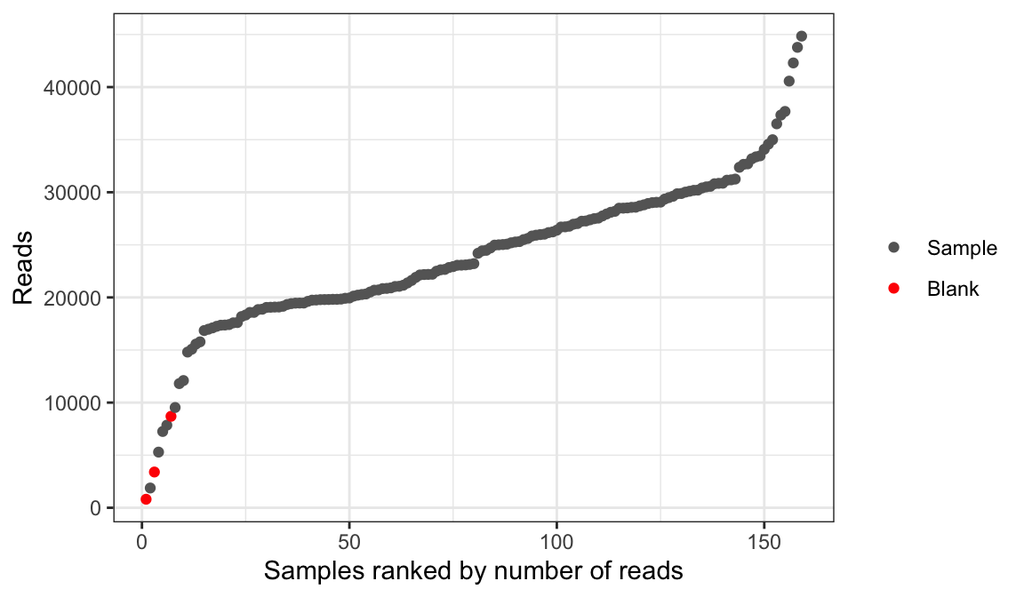

```r
tibble(Reads = rowSums(counts), is_blank = is_blank) %>%
  arrange(Reads) %>%
  mutate(Rank = row_number()) %>%
  ggplot(aes(x = Rank, y = Reads, colour = is_blank)) +
  geom_point() +
  scale_colour_manual(values = c(`FALSE` = 'grey40', `TRUE` = 'red'),
                      labels = c('Sample', 'Blank'), name = NULL) +
  labs(x = 'Samples ranked by number of reads') +
  theme_bw()
```

Blanks should have far fewer reads than samples. One of ours has more than a few real samples, which is not alarming for field blanks: they’re handled like samples and exposed to the same air.

## 6.2 Run decontam

Run decontam with the prevalence method:

```r
contam <- isContaminant(
  counts, neg = is_blank,
  method = 'prevalence', threshold = 0.1)
table(contam$contaminant)
```

```
##
## FALSE  TRUE
## 23727    38
```

## 6.3 Look at them

What proportion of blanks and of samples does each ASV appear in? `counts > 0` turns counts into `TRUE`/`FALSE` (present/absent), and `colMeans()` gives the proportion of `TRUE` for each ASV:

We’ll gather everything we need about each ASV in a single table: taxonomy, prevalence and reads in blanks and samples, and decontam’s results.

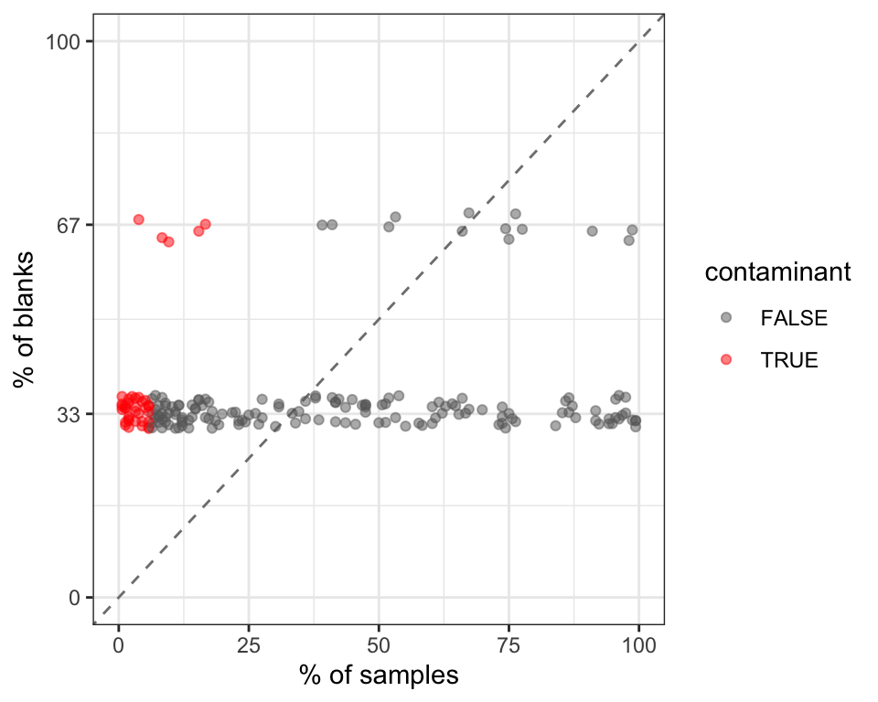

```r
asv_df <- tax_table(ps_target)[, c('Phylum', 'Family', 'Genus')] %>%
  as.data.frame() %>%
  as_tibble() %>%
  mutate(pct_blanks    = 100 * colMeans(counts[is_blank, ] > 0),
         pct_samples   = 100 * colMeans(counts[!is_blank, ] > 0),
         Reads_blanks  = colSums(counts[is_blank, ]),
         Reads_samples = colSums(counts[!is_blank, ]),
         p             = contam$p,
         contaminant   = contam$contaminant)

asv_df %>%
  filter(pct_blanks > 0) %>% # only ASVs found in at least one blank
  ggplot(aes(x = pct_samples, y = pct_blanks, colour = contaminant)) +
  geom_abline(linetype = 'dashed', colour = 'grey50') + # 1:1 line
  geom_jitter(height = 3, width = 0, alpha = 0.5) +
  scale_colour_manual(values = c(`FALSE` = 'grey40', `TRUE` = 'red')) +
  scale_x_continuous(limits = c(0, 100)) +
  scale_y_continuous(limits = c(0, 100), breaks = c(0, 33, 67, 100)) +
  labs(x = '% of samples', y = '% of blanks') +
  theme_bw()
```

Points above the dashed line are more prevalent in blanks than in samples. However, being above the line isn’t enough: decontam runs a statistical test, and with so few blanks (=little power), an ASV must be *much* more prevalent in blanks to be flagged.

What are they? Let’s look at their p-values and where their reads come from:

```r
asv_df %>%
  filter(contaminant) %>%
  arrange(p) %>%
  select(Phylum, Genus, p, Reads_blanks, Reads_samples)
```

```
## # A tibble: 38 × 5
##    Phylum           Genus                  p Reads_blanks Reads_samples
##    <chr>            <chr>              <dbl>        <dbl>         <dbl>
##  1 Bacteroidota     Chryseobacterium 0.00330          112            12
##  2 Bacillota        Neobacillus      0.0122           212            99
##  3 Bacillota        Tumebacillus     0.0157             6            96
##  4 Bacillota        Paenibacillus    0.0189           144            43
##  5 Bacillota        Fictibacillus    0.0189            13            19
##  6 Bacillota        Paenibacillus    0.0189             8             2
##  7 Bdellovibrionota Bdellovibrio     0.0189             5             4
##  8 Bacillota        Paenibacillus    0.0283            14            28
##  9 Bacillota        Cytobacillus     0.0283            31             7
## 10 Pseudomonadota   Bordetella       0.0283            21            12
## # ℹ 28 more rows
```

Do these make sense as contaminants? Many are common soil or skin bacteria. Together they represent only ~1,600 reads in our samples, so removing them has little impact.

```r
ps_decontam <- prune_taxa(!contam$contaminant, ps_target)
ps_decontam
```

```
## phyloseq-class experiment-level object
## otu_table()   OTU Table:         [ 23727 taxa and 156 samples ]
## sample_data() Sample Data:       [ 156 samples by 31 sample variables ]
## tax_table()   Taxonomy Table:    [ 23727 taxa by 6 taxonomic ranks ]
```

## 6.4 What’s left in the blanks?

decontam removed some ASVs, but the blanks still contain other taxa. Which ones, and are they also in our samples?

```r
asv_df %>%
  filter(!contaminant, Reads_blanks > 0) %>%
  arrange(desc(Reads_blanks)) %>%
  select(Phylum, Family, Genus, Reads_blanks, Reads_samples, pct_samples)
```

```
## # A tibble: 154 × 6
##    Phylum         Family            Genus Reads_blanks Reads_samples pct_samples
##    <chr>          <chr>             <chr>        <dbl>         <dbl>       <dbl>
##  1 Bacillota      Paenibacillaceae  Ammo…          991          1251       34.6
##  2 Actinomycetota Micrococcaceae    Micr…          594          5108       77.6
##  3 Actinomycetota Unclassified      Uncl…          500           335       22.4
##  4 Pseudomonadota Pseudomonadaceae  Pseu…          410          1233       57.7
##  5 Bacillota      Alicyclobacillac… Tume…          362          1004       42.3
##  6 Bacillota      Bacillaceae       Peri…          324          1668       51.3
##  7 Actinomycetota Nocardioidaceae   Noca…          304           614       30.8
##  8 Bacillota      Brevibacillaceae  Brev…          298           390       18.6
##  9 Actinomycetota Gaiellaceae       Gaie…          275           109        8.97
## 10 Bacillota      Paenibacillaceae  Ammo…          234           104        8.97
## # ℹ 144 more rows
```

Most of the ASVs that remain in blanks are also found in a large share of our samples (e.g. *Micrococcus* in over 75% of them), often with more reads than in the blanks. They could be real members of bioaerosols that ended up in the blanks, because field blanks are exposed to the same air. decontam can’t (and shouldn’t) remove these: they’re part of the signal we’re studying.

Others, like the *Gaiella* ASV, are found in few samples and have more reads in blanks. They might be contaminants that decontam didn’t have the statistical power to flag with only three blanks. Keep that in mind if one of them turns out to be important in your analyses.

**How many controls do I need?**

More is better. With few blanks, decontam has little statistical power, and its results depend a lot on which blanks you happened to collect. If your blanks are empty (they didn’t even make it through DADA2), that’s good news; it makes us more confident that there are no important contaminants.

**No blanks? Try the frequency method.**

If you measured DNA concentration for each sample, decontam can also flag ASVs whose relative abundance *decreases* as DNA concentration increases. Contaminant DNA is roughly constant, so it weighs more in low-DNA samples.

```r
# concDNA must be a column of your sample data:
contam_freq <- isContaminant(
  ps_target, conc = 'concDNA',
  method = 'frequency', threshold = 0.1)
table(contam_freq$contaminant)
```

# 7 Remove low-depth samples

We already removed the failed sample (the one with 21 reads), but remember `22-E-SHER-SH09`?

```r
sample_sums(ps_decontam) %>% sort() %>% head()
```

```
## 22-E-SHER-SH09 22-A-SHER-SH08 22-A-SHER-SH12 22-A-SHER-SH13 22-E-SHER-SH10
##           1879           5262           7253           7696           9534
## 22-S-SHER-SH01
##          11804
```

There’s a big gap between the smallest sample and the rest. We can choose to drop samples with fewer than a certain number of reads.

`prune_samples()` works like `prune_taxa()`, but on samples:

```r
ps_depth <- prune_samples(sample_sums(ps_decontam) >= 5000, ps_decontam) %>%
  prune_taxa(taxa_sums(.)>0, .) # always flush the all-zero ASVs
```

**There is no objectively good threshold**. Here, we see what we consider to be an outlier, and we decide that 1879 reads is not enough. Look at your own distribution and find where the “tail” of low samples starts. Rarefaction curves (`vegan::rarecurve()`) can also help.

# 8 Remove rare ASVs

ASVs with very few reads across the whole dataset can either be extremely rare variants or sequencing errors that DADA2 couldn’t resolve. Let’s see how many ASVs have fewer than 10 reads, and how many reads they represent:

```r
rare <- taxa_sums(ps_depth) < 10
sum(rare)                     # number of rare ASVs
```

```
## [1] 8648
```

```r
sum(taxa_sums(ps_depth)[rare]) / sum(taxa_sums(ps_depth)) # proportion of reads
```

```
## [1] 0.01264349
```

About **a third of all our ASVs** have fewer than 10 reads *total*, but together they represent ~1% of reads. This is typical: most ASVs are rare, and most reads come from a few abundant ASVs.

```r
ps_final <- prune_taxa(taxa_sums(ps_depth) >= 10, ps_depth)
ps_final
```

```
## phyloseq-class experiment-level object
## otu_table()   OTU Table:         [ 15070 taxa and 155 samples ]
## sample_data() Sample Data:       [ 155 samples by 31 sample variables ]
## tax_table()   Taxonomy Table:    [ 15070 taxa by 6 taxonomic ranks ]
```

Like the depth threshold, 10 is arbitrary. Removing these ASVs lowers presence-absence metrics like richness, but they barely matter for abundance-aware metrics, and rarefaction would remove most of them anyway. It makes the dataset lighter, but it’s a decision you need to be able to justify.

# 9 Final object

Save it! This is the object you’ll use for all downstream analyses, like the community composition tutorial.

```r
write_rds(ps_final, 'ps_16S_clean.rds')
```

# 10 Report

What did we lose along the way? Let’s write a small function that counts samples, ASVs and reads in a phyloseq object, then use it on the object from each step. `bind_rows()` stacks the results, and `.id` turns the names we give into a `Step` column:

```r
count_ps <- function(ps) {
  tibble(Samples = nsamples(ps),
         ASVs    = ntaxa(ps),
         Reads   = sum(sample_sums(ps)))
}

report <- bind_rows(
  'Study samples'             = count_ps(ps_raw),
  'Failed sample removed'     = count_ps(ps_nonempty),
  'Non-target taxa removed'   = count_ps(ps_target),
  'Contaminants removed'      = count_ps(ps_decontam),
  'Low-depth samples removed' = count_ps(ps_depth),
  'Rare ASVs removed'         = count_ps(ps_final),
  .id = 'Step') %>%
  mutate(`ASVs removed`  = lag(ASVs) - ASVs,
         `Reads removed` = lag(Reads) - Reads,
         `% initial reads kept`  = round(100 * Reads / first(Reads), 1))
report
```

```
## # A tibble: 6 × 7
##   Step                      Samples  ASVs   Reads `ASVs removed` `Reads removed`
##   <chr>                       <int> <int>   <dbl>          <int>           <dbl>
## 1 Study samples                 157 23898 3808179             NA              NA
## 2 Failed sample removed         156 23898 3808158              0              21
## 3 Non-target taxa removed       156 23765 3782898            133           25260
## 4 Contaminants removed          156 23727 3781293             38            1605
## 5 Low-depth samples removed     155 23718 3779414              9            1879
## 6 Rare ASVs removed             155 15070 3731629           8648           47785
## # ℹ 1 more variable: `% initial reads kept` <dbl>
```

Add the non-target breakdown and format in an exportable table:

```r
breakdown <- nontarget_summary %>%
  transmute(Step = reason, `ASVs removed` = ASVs, `Reads removed` = Reads)

report_full <- bind_rows(report[1:3, ], breakdown, report[4:6, ])

report_kable <- report_full %>%
  kable(format.args = list(big.mark = ','),
        caption = 'Samples, ASVs and reads at each post-processing step') %>%
  kable_styling(full_width = FALSE) %>%
  add_indent(4:(3 + nrow(breakdown)))

report_kable
```

Table 10.1: Table 10.2: Samples, ASVs and reads at each post-processing step

| Step | Samples | ASVs | Reads | ASVs removed | Reads removed | % initial reads kept |
| --- | --- | --- | --- | --- | --- | --- |
| Study samples | 157 | 23,898 | 3,808,179 |  |  | 100.0 |
| Failed sample removed | 156 | 23,898 | 3,808,158 | 0 | 21 | 100.0 |
| Non-target taxa removed | 156 | 23,765 | 3,782,898 | 133 | 25,260 | 99.3 |
| Chloroplast |  |  |  | 14 | 272 |  |
| Mitochondria |  |  |  | 47 | 23,982 |  |
| Non-bacterial |  |  |  | 8 | 77 |  |
| Unclassified phylum |  |  |  | 64 | 929 |  |
| Contaminants removed | 156 | 23,727 | 3,781,293 | 38 | 1,605 | 99.3 |
| Low-depth samples removed | 155 | 23,718 | 3,779,414 | 9 | 1,879 | 99.2 |
| Rare ASVs removed | 155 | 15,070 | 3,731,629 | 8,648 | 47,785 | 98.0 |

```r
save_kable(report_kable, 'postprocessing_report.html')
```

We lost over a third of the ASVs, but only ~2% of the reads. That’s what we want: the removed ASVs were super rare, and the bulk of the signal is still there.